# Manuscript

2021-08-06

## Results

### First session

| Session | Source | Records | % over total | Source specific records | % over source total |
| --- | --- | --- | --- | --- | --- |
| Session1 | Total | 17755 |  |  |  |
|  | Embase | 12719 | 71.6% | 6683 | 52.5% |
|  | Pubmed | 9546 | 53.8% | 3457 | 36.2% |
|  | Scopus | 3175 | 17.9% | 298 | 9.39% |
|  | WOS | 2100 | 11.8% | 473 | 22.5% |
|  | IEEE | 60 | 0.34% | 29 | 48.3% |
| Session2 | Total | 82579 |  |  |  |
|  | Embase | 48396 | 58.6% | 40826 | 84.4% |
|  | Pubmed | 28811 | 34.9% | 18021 | 62.5% |
|  | Scopus | 17070 | 20.7% | 4908 | 28.8% |
|  | WOS | 12956 | 15.7% | 2817 | 21.7% |
|  | IEEE | 61 | 0.074% | 22 | 36.1% |
| All Sessions | Total | 98371 |  |  |  |
|  | Embase | 59604 | 60.6% | 46942 | 78.8% |
|  | Pubmed | 37278 | 37.9% | 21371 | 57.3% |
|  | Scopus | 19353 | 19.7% | 5181 | 26.8% |
|  | WOS | 14367 | 14.6% | 3175 | 22.1% |
|  | IEEE | 108 | 0.11% | 48 | 44.4% |

Table 1. Distribution of retrieved records by source and session. For each source it is reported the number of records, percentage over the session total (after removing duplicates)’ and, number or records specific for a source as absolute value and as percentage over the source total. SAll session shows records after joining and deduplication of the Session1 and Session2 dataset.

After the first manual classification, 7 automatic classification and manual review rounds (CR) were performed (Table 2). It is possible to observe how the number of records that required manual review dropped fast between iterations, indicating that the engine was converging while the uncertainties were resolved.  
This phenomenon is better depicted in figure 1 in the Suppl. Mat. S2. It shows the mixture distribution of the predicted probabilities for each record, specifically for the reviewed positive and negative records, and for records that need manual review after the classification step: it can be noticed how the distribution of the uncertain records shrinks (they concentrate in a shorter probability range) and shifts toward the negative zone as more positive matches are found and reviewed. Accordingly (Table 2), the number of new positives found drops after the first couple of iterations. As per default, the classification process was stopped after four rounds with no new positive matches; a total number of 101 positives were found over 766 manually reviewed records (13.2% positivity rate).

| Session | Iteration | Positives | Negatives | Total labelled (%) | Unlab. -> y | Unlab. -> n | Unlab. -> * | n -> y | Changes | N. features |
| --- | --- | --- | --- | --- | --- | --- | --- | --- | --- | --- |
| Session1 (n = 17755) | Initial labelling | 43 | 207 | 250 (1.41%) | 43 | 207 | 0 | 0 | 250 | 2289 |
|  | 1 | 93 | 529 | 622 (3.5%) | 50 | 322 | 0 | 0 | 372 | 2289 |
|  | 2 | 100 | 614 | 714 (4.02%) | 6 | 86 | 0 | 1 | 93 | 3750 |
|  | 3 | 101 | 625 | 726 (4.09%) | 1 | 11 | 0 | 0 | 12 | 3834 |
|  | 4 | 101 | 648 | 749 (4.22%) | 0 | 23 | 0 | 0 | 23 | 3856 |
|  | 5 | 101 | 651 | 752 (4.24%) | 0 | 3 | 0 | 0 | 3 | 3856 |
|  | 6 | 101 | 660 | 761 (4.29%) | 0 | 9 | 0 | 0 | 9 | 3856 |
|  | 7 | 101 | 665 | 766 (4.31%) | 0 | 5 | 0 | 0 | 5 | 3856 |
| Session2 (n = 98371) | 1 | 106 | 934 | 1040 (1.06%) | 5 | 270 | 998 | 0 | 1273 | 4729 |
|  | 2 | 107 | 1123 | 1230 (1.25%) | 1 | 189 | 0 | 0 | 190 | 4729 |
|  | 3 | 107 | 1176 | 1283 (1.3%) | 0 | 53 | 0 | 0 | 53 | 4733 |
|  | 4 | 107 | 1200 | 1307 (1.33%) | 0 | 24 | 0 | 0 | 24 | 4729 |
|  | 5 | 107 | 1209 | 1316 (1.34%) | 0 | 9 | 0 | 0 | 9 | 4729 |
|  | 6 | 107 | 1226 | 1333 (1.36%) | 0 | 17 | 0 | 0 | 17 | 4729 |

Table 2. Results of the automatic classifaction and manual review rounds. For each iteration, the cumulative number of positives and negative records and their sum (Total labelled) and percentage over total are shown. Also, the number of changes after review and their description is reported. “Unlab.” indicates unlabelled records marked for review. For each Iteration, also the number of features used by the engine is reported. The first row reports the results of the initial manual labelling of records, which acted as input for the automatic classification in Iteration 1. In Session2, the engine uses the labels at the end of Session1 to classify the newly added records.

By evaluating how often the BART algorithm decided to use a term for classification, it is possible to list a subset of the variables most relevant for the classification of the documents: Patient Transport (Keyword): 61.2
$$21.3$$
, Transfer (Abstract): 57
$$15.4$$
, Network (Title): 56.5
$$14.2$$
, Network & Patient (Abstract): 54.2
$$15.2$$
, Donker T (Author): 53.5
$$16.5$$
, Worker (Abstract): 50
$$-1.21$$
, Hospitals (Keyword): 49.8
$$16.5$$
, Movement (Abstract): 47.8
$$15$$
, Spread (Title): 46.6
$$12.1$$
, Facility (Abstract): 45
$$14.8$$
, Orange County (Keyword): 44.3
$$17.2$$
, Conduct (Abstract): 42.6
$$-2.57$$
, Patient (Abstract): 42
$$7.23$$
, Perform (Abstract): 41.9
$$-2.55$$
, Hospital (Title): 39
$$12.5$$
. In parenthesis, it is reported the part of the record in which the term was used, while the numeric values indicate respectively the rate of posterior trees (over 10000 trees) in which a term was used, and the number of standard errors of the association between a term and the probability of a positive match according to a simple logistic linear model (see methods). The “&” indicates that two terms are present together in a document but not close to each other.
The engine was able to pick up the central concept of the research (i.e., “patient transport” or “transfer” through a “network” of “facility”ies that facilitates the “spread” of infections) and even one of the authors of the current study (Donker T.) or the region of interest (“Orange County”) of another research group active on the topic. It is interesting to see that some terms were considered highly relevant (e.g., “Worker” in 6th position out of more than 3800 terms considered) although in a simpler linear model, their effect would be hardly significant (statistic: -1.21 se), and this highlight the extra predictive power brought by a highly non-linear model.
A more extensive set of terms is presented in Table 1 of Supplemental Material S2.

### Second session

The results of the first classification session were used to create a second, data-driven query with the purpose of performing a more large-spectrum search to find records which may have escape the first search session. The resulting query was the following:

*(((Donker T) NOT (bacterium isolate)) OR ((network patient) AND (resistant staphylococcus aureus) NOT (monte carlo) NOT isolation) OR (facility AND (network patient) AND regional NOT hospitals NOT increase NOT (patient transport) NOT (control infection use)) OR ((patient transport) NOT (Donker T) NOT worker) OR (hospitals AND (network patient) NOT (patient transport) NOT regional NOT clinical) OR (facility AND (network patient) NOT hospitals NOT (patient transport) NOT regional NOT prevention NOT medical) OR ((healthcare facility) NOT (Donker T) NOT worker NOT positive) OR (hospitals NOT (network patient) NOT medical NOT environmental NOT outcome NOT global) OR ((network patient) NOT facility NOT hospitals NOT (patient transport) NOT therapy NOT global)) AND ((antimicrobial resistance) OR (healthcare infection))*

The final piece *AND ((antimicrobial resistance) OR (healthcare infection)* was added manually to better define the search domain, since the algorithm was trained on documents that were all more or less related to these topics.  
The generated query also provides a more nuanced understanding of the engine’s internal classification logic, and this is helpful to spot possible biases in the model.

The new search produced 107294 records (Table 1), of which 48396 (58.6%) from the *EMBASE*, followed by 28811 (34.9%) from *Pubmed/Medline*, 17070 (20.7%) from *Scopus*, 12956 (15.7%) from *Web of Science*, and 61 (0.074%) from *IEEE*; compared to the first session, the relative weight of *EMBASE* and *Pubmed* over the total was decreased, while the amount of content specificity was greatly increased, as it was for *Scopus*. After removal of duplicates, 82579 unique records were obtained. Once joined with the session 1 records and duplicates removed, we obtained 98371 unique records, with just 1963 shared records between searches, that is the 2%. The percentage of records shared by two or more source dropped to 22%.

Six CR rounds were necessary to complete the second session classification, with just 6 new positive found after reviewing 568 extra records. It is interesting to notice that the first CR round required the user to review a substantial number of records (1273), but just labelling 275 of them (the canonical 250 plus 25 that were already labelled during the framework performance evaluation) was sufficient to drop this number to just 190 in the subsequent round. An evaluation of the convergence (Figure 1, Suppl. Mat. S2) showed that, in addition to the dynamics already observed in session 1 (shrinkage and negative shift), a second mode appeared in the mixture distribution of the records to be reviewed, centred in a highly positive zone. The interpretation is that as the number of negative training records increases, the engine gets more and more sceptical and asks to review even some records labelled as positive in the initial labelling at the beginning of session 1. This behaviour can be useful to spot classification errors and inconsistencies. Considering both sessions, 1333 records were reviewed and 107 (8.03%) were found.

Again, the evaluation of the relative importance of the terms showed that the engine was quite capable of internalizing the concepts behind the research topic. A subsample of these terms is reported in Table 2 of Suppl. Mat. S2.

### Hyperparameter selection and performance evaluation

As described in the methods, the selection of hyperparameters was achieved via the evaluation of sensibility and efficiency with a grid search on a subset of 1200 completely manually labelled records (validation set). The best set of parameters suggested an initial input of 250 labelled records, an averaged ensemble of 10 models, no bootstrapping and an uncertainty zone defined by the 98% predictive interval. On the validation set, this combination of parameters reached a sensitivity of 98.8% (81 / 82 positive matches found) and efficiency of 61.5% (462 / 1200 records evaluated). A summary of the results of the grid search is reported in Table 3 in Suppl. Mat. S2.

To evaluate the theoretical performance of the engine on the full datasets (i.e., session1 and session2 data), a Bayesian logistic model was trained on each session dataset to predict the label of the records from the probability estimated by the engine (see methods for details). The performance of such simple models is quite high (Bayesian R2: 98.1%
$$97.4%, 98.3%$$
for session 1 and 98.2%
$$97.6%, 98.3%$$
for session 2) and the median of their cumulative predictive distribution matches quite well the actual number of cumulative positive records found. The predicted cumulative number of positive matches was used to evaluate the performance in the non-reviewed records (Table 3).

| Indicator | Session 1 | Session 2 |
| --- | --- | --- |
| Tot. records | 17755 | 98371 |
| N. reviewed records (% over total) | 761 (4.29%) | 1316 (1.34%) |
| Expected efficiency $$PrI$$ | 95.7% $$95.3%, 95.7%$$ | 98.6% $$98.2%, 98.7%$$ |
| N. positive matches (% over total) | 101 (0.57%) | 107 (0.11%) |
| Predicted positive matches $$PrI$$ | 101 $$101, 108$$ | 110 $$107, 145$$ |
| Expected sensitivity $$PrI$$ | 100% $$93.5%, 100%$$ | 97.3% $$73.8%, 100%$$ |
| Simple Model R^2 $$PrI$$ | 98.1% $$97.4%, 98.3%$$ | 98.2% $$97.6%, 98.3%$$ |

Table 3. Estimated performance summary. For each session, the number of reviewed records and the percentage over the total provide an idea of the work saved against manually labelling all retrieved records. Using a simple logistic model to predict a positive match from the probabilities outputted by the engine, the predictive distribution of the cumulative number of positive matches was computed and used to estimate the sensitivity and the efficiency of the engine for each session. Finally the Bayesian R^2 of the logistic models is reported.
$$PrI$$
represents the 90% Predictive Interval.

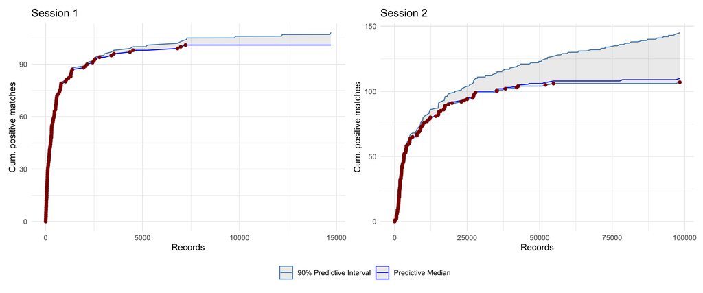

Figure 1. 90% Predictive distribution of the cumulative number of positive matches estimated by the logistic Bayesian models applied to the engine output. The distribution is depicted by the shaded area. The distribution is cut at the level of the observed cumulative distribution of positive matches (red dots), since there cannot be false positive in the dataset and predicted value below this line are not possible.